# Assignment 3

## Try to submit as an HTML file

Print your name below

```python
print("Daisy Cossio Garica")
```

```
Daisy Cossio Garica
```

Import the numpy and matplotlib packages

```python
import numpy as np
import matplotlib.pyplot as plt
```

(a) Compute a formula:

$V=P\left(1+{\frac {r}{n}}\right)^{nt}$

Calculate $V$ when

- $P = 2100 $
- $r = 0.034$
- $n = 4$
- $t = 7$

To get full points:

- First define each of these variables
- Write the formula above

```python
# Note (if you're interested in the context)
# V = Accumulated value of investment
# P =  Principal (the amount deposited)
# r =  Quarterly interest rate
# n = Number of quarters in a year
# t = number of years

P = 2100
r = 0.034
n = 4
t = 7

V = (P * (1 + r / n)** (n * t))
print(str(V))
```

```
2661.6108980682593
```

(b) Composite operations on arrays

- Define $r = 0.04"
- Define two arrays $A$ and $T$ using "np.array()", assigning the following values

$ a = \begin{pmatrix} a_1 \\ a_2 \\ a_3 \end{pmatrix} = \begin{pmatrix} 20 \\ 30 \\ 15 \end{pmatrix}, \qquad t = \begin{pmatrix} t_1 \\ t_2 \\ t_3 \end{pmatrix} = \begin{pmatrix} 0 \\ 1 \\ 2 \end{pmatrix} $

- Use element-by-element vector operations to compute a new array $M$ of length 3:

$ M = \begin{pmatrix} a_1 / (1+r)^{t_0} \\ a_2 / (1+r)^{t_1} \\ a_3 / (1+r)^{t_2} \end{pmatrix} $

- Compute the sum of the values of $M$ using "M.sum()"

Note: I am using subscripts to denote the individual elements of $a$ and $t$.

- In the code just enter the values of $a$ and $t$.
- To get full points you must do all of the above tasks

```python
r= 0.04
a = np.array([20, 30, 15])
t = np.array([0, 1, 2])
m1= a[0] / (1 + r) ** t [0]
m2= a[1] / (1 + r) ** t [1]
m3= a[2] / (1 + r) ** t [2]
M = np.array([m1, m2, m3])
print(str(M))
Msum = M.sum()
print(Msum)
```

```
[20.         28.84615385 13.8683432 ]
62.71449704142012
```

(c) Plot a normal random variable

To get full points:

- Set a seed using "np.random.seed()"
- Create a normal random variable with the following parameters

mean = 5, standard deviation = 2, and size = 1000

- Create a histogram
- Label the axes

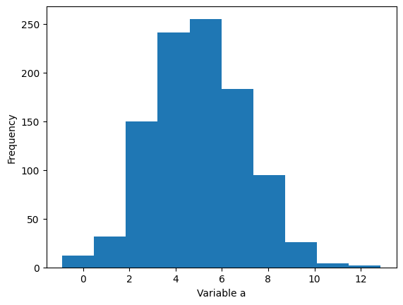

```python
np.random.seed(12345)
normal_var = np.random.normal(loc= 5, scale= 2, size= 1000)
plt.hist(x = normal_var)
plt.xlabel("Variable a")
plt.ylabel("Frequency")
```

(d) Checking a string condition

- Define a variable "fruit" with the value "apple"
- Define a list

list_fruits = ["banana","orange","apple"]

- Write an expression to test whether "fruit" is contained in "list_fruits"

Hint: Use the "in" command. The final output should be True/False.

To get full points run all of the above commands

```python
fruit = "apple"
print(fruit)
list_fruits = ["banana", "orange", "apple"]
print(str(list_fruits))
answer = fruit in list_fruits
print(str(answer))
```

```
apple
['banana', 'orange', 'apple']
True
```

(e) Classifying a variable

- Define a new variable "year" and assign the value "2008"
- Write an if/else statement that does the following
  - print("Year 2000 or earlier") if the year is less than or equal to 2000.
  - print("Between 2001 and 2005") if the year is between 2001 and 2005.
  - print("Year 2006 or later") if the year is after 2005.

To get full points you must do all of the above instructions

```python
year = 2008
if year <= 2000:
    print ("Year 2000 or earlier")
elif (year > 2000) & (year < 2006):
    print ("Between 2001 and 2005")
else:
     print ("2006 or later")
```

```
2006 or later
```